# Scores - PrevenDIAB (vers. 01.2024)

Emma Henriques

2025-02-13

# 1 Chargement des données

On charge la base de données sur laquelle appliquer les scores (sous-groupe cas/témoins : N=144).

=> Possibilité de choisir entre la base complète, soit la population totale, et entre la base réduite, soit le sous-groupe cas/témoins.

# 2 Score Métabolique

## 2.1 Introduction à la préparation des données

sur la base de la définition mondiale du syndrome métabolique de la Fédération internationale du diabète (FID).

Le calcul du **score Métabolique** se base sur la définition mondiale du syndrome Métabolique de la Fédération internationale du diabète (*the International Diabetes Federation (IDF)*).

D’après les critères ATP-III, seulement 3 critères sur les 5 sont requis afin d’être diagnostiqué.

Plus précisémment, le diagnostique requiert la présence d’un IMC > 30 kg/m2 ou un tour de taille (=1ère condition) supérieur au seuil ethnique, plus 2 des 5 autres critères.

- tour de taille ≥ à 102 cm (40 Inches) pour les hommes ; ≥ à 88 cm (35 inches) pour les femmes
- taux de Triglycérides ≥ 150 mg/dL (1.7 mmol/L)
- HDL < 40 mg/dL (1.03 mmol/L) pour les hommes ; < 50 mg/dL (1.29 mmol/L) pour les femmes
- Pression artérielle ≥ 130 / 85 mm Hg
- Glycémie à jeun ≥ 110 mg/dL (5.6 mmol/L)

### 2.1.1 Calculateur en ligne

Le [calculateur en ligne](https://qxmd.com/calculate/calculator_120/metabolic-syndrome-idf) utilisé par l’IPL utilise les variables suivantes :

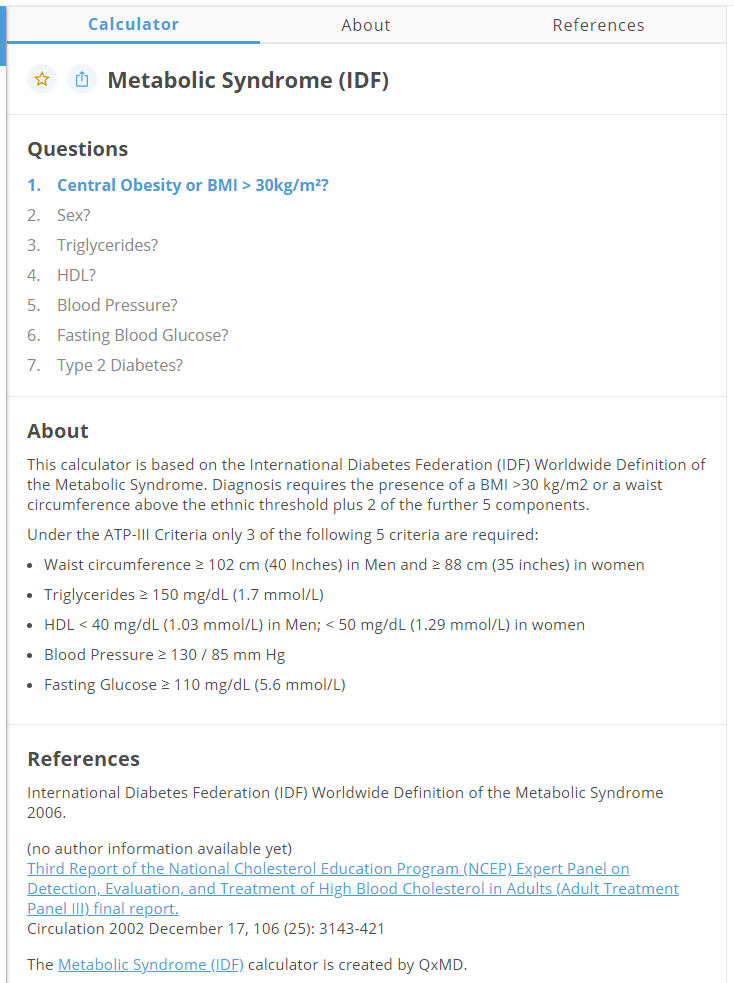

Plus d’informations pour le tour de taille du calculateur : (=> onglet *central obesity*)

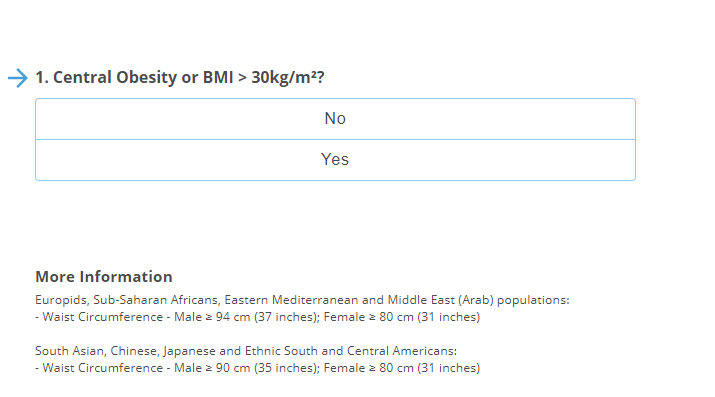

- Europids, Sub-Saharan Africans, Eastern Mediterranean and Middle East (Arab) populations:
  - Waist Circumference - Male ≥ 94 cm (37 inches); Female ≥ 80 cm (31 inches)
- South Asian, Chinese, Japanese and Ethnic South and Central Americans:
  - Waist Circumference - Male ≥ 90 cm (35 inches); Female ≥ 80 cm (31 inches)

### 2.1.2 Echanges et discussions

Suite aux échanges avec l’IPL, les points retenus sont les suivants :

- Pour l’obesité centrale *(Central obesity)*, on considère **l’IMC ou le tour de taille**
  - au moins une des deux informations doit être vraie pour impliquer l’obésité !
  - pour le tour de taille : prendre en compte l’origine ethnique et/ou la catégorie raciale

=> Pour le calcul de ce score, pour déterminer le diagnostique, il est important d’avoir au moins l’obésité centrale comme 1er critère, en plus de 2 autres critères (minimum) parmi :

- le taux de triglycérides,
- le taux de cholestérol HDL,
- la pression artérielle systolique allongée
- le taux de flycémie à jeun
- le statut diabétique (type 2) -> *information à venir*

Remarque :

si l’obésité centrale ne fait pas partie des critères, alors il ne peut y avoir de diagnotique établit

## 2.2 Préparation des données

On va donc préparer les données, soit les variables nécessaires au calcul du score Métabolique.

### 2.2.1 Obésité centrale :

- IMC > 30 kg/m² OU tour de taille (cm) :
  - *Europids, Sub-Saharan Africans, Eastern Mediterranean and Middle East (Arab) populations:*
    - *Waist Circumference - Male ≥ 94 cm (37 inches); Female ≥ 80 cm (31 inches)*
  - *South Asian, Chinese, Japanese and Ethnic South and Central Americans:*
    - *Waist Circumference - Male ≥ 90 cm (35 inches); Female ≥ 80 cm (31 inches)*

=> on va utiliser les variables d’origine ethnique ou de catégorie raciale pour pouvoir établir cette variable :

**Pour les femmes :** Tour de taille ≥ 80 cm peu importe l’origine ethnique ou la catégorie raciale

**Pour les hommes :**

- Tour de taille ≥ 94cm :
  - Origine ethinique := Caucasien|Nord-africain|Africain|Amérindien|Autres|Non disponible|NA
  - Catégorie raciale := Blanche|Noire|Moyen-orientale|Autres|Non disponible|NA
- Tour de taille ≥ 90 cm :
  - Origine ethinique := Asiatique|Polynésien
  - Catégorie raciale := Est - asiatique|Sud - asiatique|Asiatique du Sud-Est|Latino

*Remarque : Pour les valeurs non disponible, autres et NA, j’ai décidé d’utiliser le seuil le plus large/stricte (pour éviter de potentielle “erreurs”).*

| Central Obesity | Freq |
| --- | --- |
| FALSE | 45 |
| TRUE | 99 |
| Sum | 144 |

### 2.2.2 Sexe :

Le genre va être à prendre en compte dans les seuils comme pour l’obésité centrale, le taux de cholestérol HDL, …

| Gender | Freq |
| --- | --- |
| F | 62 |
| M | 82 |
| Sum | 144 |

### 2.2.3 Taux de Triglycérides :

Le seuil pour le taux de triglycérides est le suivant :

- ≥ 1.7 mmol/L

=> Conversion des données en g/L par 1.14 pour avoir des mmol/L *(https://www.sfcardio.fr/page/chapitre-3-item-223-dyslipidemies)*  
*(je garde 1 chiffre après la virgule, pour s’approcher de la précision du seuil donné)*

| Taux de Triglycérides (≥ 1.7 mmol/L) | Freq |
| --- | --- |
| FALSE | 113 |
| TRUE | 31 |
| Sum | 144 |

### 2.2.4 Taux de cholestérol HDL :

Le seuil pour le taux de cholestérol HDL est le suivant :

- < 1.29 mmol/L pour les femmes
- < 1.03 mmol/L pour les hommes

=> Conversion des données en g/L par 2.58 pour avoir des mmol/L *(https://www.sfcardio.fr/page/chapitre-3-item-223-dyslipidemies)* *(je garde 2 chiffre après la virgule, pour s’approcher de la précision des seuils donnés)*

| Taux de cholestérol HDL (< 1.29 mmol/L - femmes ; < 1.03 mmol/L - hommes) | Freq |
| --- | --- |
| FALSE | 112 |
| TRUE | 32 |
| Sum | 144 |

### 2.2.5 Pression Artérielle Systolique allongée :

Le seuil pour la pression artérielle systolique allongée est le suivant :

- ≥ 130/85 mmHg

| Pression Artérielle Systolique Allongée (≥ 130/85 mmHg) | Freq |
| --- | --- |
| FALSE | 45 |
| TRUE | 99 |
| Sum | 144 |

### 2.2.6 Glycémie à jeun :

Le seuil pour la Glycémie à jeun est le suivant :

- ≥ 1.10 g/L (soit ≥ 110 mg/dL (5.6 mmol/L))

*Remarque : La mesure de la glycémie à jeun est présente en g/L dans nos données et en mg/dL dans le calculateur.*

| Glycémie à jeun - (≥ 1.10 g/L) | Freq |
| --- | --- |
| FALSE | 117 |
| TRUE | 27 |
| Sum | 144 |

### 2.2.7 Diabète de type 2 :

*Remarque : Cette variable est en attente de la part de l’IPL, celle-ci faisant passer le nombre total de critères possibles de 5 à 6.*

D’après le plan d’analyse, le diabète est déterminé à partir de la glycémie à jeun (> 1.25g/L). ou Diabète connu (:= également critère de non inclusion - ).  
Pour l’instant, afin d’implémenter le score, j’ai utilisé la manière de procéder suivante : je crée la variable de T2D à partir de la glycémie à jeun (> 1.25g/L) **OU** de la variable de diabète connu (considéré comme critère de non-inclusion). Il est à noter que cela va créer une redondance avec l’information de la glycémie à jeun (≥ 1.10g/L), en se basant sur cette “méthode”.

| Diabète - Glycémie > 1.25g/L | Freq |
| --- | --- |
| Diabète | 4 |
| Glycémie normale | 72 |
| Prédiabète niveau 1 | 47 |
| Prédiabète niveau 2 | 21 |
| Sum | 144 |

| Diabète critère | Freq |
| --- | --- |
| FALSE | 140 |
| TRUE | 4 |
| Sum | 144 |

## 2.3 Calcul du score Métabolique

Pour le calcul du score, on va compter le nombre de critères remplis de chaque individus (au minimum 3 pour être diagnostiqué).  
En prenant soin de vérifier que l’obésité centrale en fait partie.

### 2.3.1 Score Métabolique

| Metabolic syndrome - Criteria count | Freq |
| --- | --- |
| 0 | 12 |
| 1 | 33 |
| 2 | 59 |
| 3 | 23 |
| 4 | 14 |
| 5 | 2 |
| 6 | 1 |

| Metabolic syndrome diag / crit | FALSE | TRUE |
| --- | --- | --- |
| 0 | 12 | 0 |
| 1 | 33 | 0 |
| 2 | 59 | 0 |
| 3 | 3 | 20 |
| 4 | 0 | 14 |
| 5 | 0 | 2 |
| 6 | 0 | 1 |

|  | Patient_ID | Obesité Centrale | Triglycerides | Cholesterol HDL | Pression artérielle systolyque | Glycémie à jeun | Syndrome Metabolique criteres (count) | Syndrome Metabolique (diag) | Diabete T-II | SyndMetab_ON | SyndMetabo_Res | AgeMeta_V1 | AgeMeta | Grp_C_T | IMC | TG1_TRIGLYCERIDES | HDLH_CHOLESTEROL_HDL | PAS | G_GLYCEMIE_à_jeun |
| --- | --- | --- | --- | --- | --- | --- | --- | --- | --- | --- | --- | --- | --- | --- | --- | --- | --- | --- | --- |
| 1 | 1-0006 | True | False | True | True | False | 3 | True | False | Fait | Oui |  | 56 | Temoin | 44.88 | 1.18 | 0.39 | 151 | 0.98 |
| 2 | 1-0019 | True | False | False | True | False | 2 | False | False | Fait | Non |  | 43 | Temoin | 26.83 | 1.07 | 0.53 | 130 | 0.9 |
| 3 | 1-0026 | False | False | False | True | True | 2 | False | False | Fait | Non |  | 27 | Cas | 21.67 | 0.82 | 0.47 | 154 | 1.15 |
| 4 | 1-0027 | True | False | True | True | False | 3 | True | False | Fait | Oui |  | 70 | Cas | 31.4 | 1.03 | 0.39 | 149 | 1.03 |
| 5 | 1-0030 | True | True | True | False | True | 4 | True | False | Fait | Oui |  | 67 | Cas | 31.72 | 4.96 | 0.28 | 96 | 1.18 |
| 6 | 1-0038 | False | True | True | True | False | 3 | False | False | Fait | Non |  | 41 | Temoin | 22.84 | 2.7 | 0.32 | 151 | 0.97 |
| 7 | 1-0045 | True | False | False | True | False | 2 | False | False | Fait | Oui |  | 54 | Cas | 34.91 | 0.69 | 0.51 | 192 | 1.05 |
| 8 | 1-0060 | True | False | False | False | False | 1 | False | False | Fait | Non |  | 69 | Temoin | 30.69 | 0.86 | 0.63 | 112 | 0.85 |
| 9 | 1-0070 | True | False | False | True | False | 2 | False | False | Fait | Oui |  | 53 | Cas | 29.07 | 1.38 | 0.47 | 135 | 1.03 |
| 10 | 1-0072 | False | False | False | True | False | 1 | False | False | Fait | Non |  | 12 | Temoin | 18.95 | 0.84 | 0.53 | 130 | 0.86 |

[output cut: 134 more lines]

### 2.3.2 Statistiques descriptives

[output not shown]

<sup>1</sup> n (%)

### 2.3.3 Comparaison

| Metabolic syndrome diag (eh) VS from data |  | Non | Oui |
| --- | --- | --- | --- |
| FALSE | 1 | 91 | 15 |
| TRUE | 0 | 2 | 35 |

|  | Patient_clean | result_metabolic_syndrome_diag | SyndMetabo_Res |
| --- | --- | --- | --- |
| 1 | 1-0006 | True | Oui |
| 2 | 1-0019 | False | Non |
| 3 | 1-0026 | False | Non |
| 4 | 1-0027 | True | Oui |
| 5 | 1-0030 | True | Oui |
| 6 | 1-0038 | False | Non |
| 7 | 1-0045 | False | Oui |
| 8 | 1-0060 | False | Non |
| 9 | 1-0070 | False | Oui |
| 10 | 1-0072 | False | Non |

[output cut: 134 more lines]

### 2.3.4 Mesures

|  | Patient_clean | gender | IMC | tr_taille | TRIGLYCERIDES_mmol | HDL_CHOLESTEROL_mmol | PAS | G_GLYCEMIE_à_jeun | result_metabolic_syndrome_diag | SyndMetabo_Res |
| --- | --- | --- | --- | --- | --- | --- | --- | --- | --- | --- |
| 1 | 1-0006 | M | 44.88 | 135 | 1.3 | 1.01 | 151 | 0.98 | True | Oui |
| 2 | 1-0019 | F | 26.83 | 89 | 1.2 | 1.37 | 130 | 0.9 | False | Non |
| 3 | 1-0026 | M | 21.67 | 79 | 0.9 | 1.21 | 154 | 1.15 | False | Non |
| 4 | 1-0027 | M | 31.4 | 110 | 1.2 | 1.01 | 149 | 1.03 | True | Oui |
| 5 | 1-0030 | M | 31.72 | 117 | 5.7 | 0.72 | 96 | 1.18 | True | Oui |
| 6 | 1-0038 | M | 22.84 | 82.5 | 3.1 | 0.83 | 151 | 0.97 | False | Non |
| 7 | 1-0045 | F | 34.91 | 101.5 | 0.8 | 1.32 | 192 | 1.05 | False | Oui |
| 8 | 1-0060 | F | 30.69 | 90 | 1 | 1.63 | 112 | 0.85 | False | Non |
| 9 | 1-0070 | M | 29.07 | 97 | 1.6 | 1.21 | 135 | 1.03 | False | Oui |
| 10 | 1-0072 | M | 18.95 | 72 | 1 | 1.37 | 130 | 0.86 | False | Non |

[output cut: 134 more lines]

```
       Non Oui
```

# 3 Score Framingham

## 3.1 Introduction à la préparation des données

Concernant le score Framingham, on se base sur la publication suivante : [General Cardiovascular Risk Profile for Use in Primary Care | Circulation (ahajournals.org)](https://www.ahajournals.org/doi/10.1161/CIRCULATIONAHA.107.699579?url_ver=Z39.88-2003&rfr_id=ori:rid:crossref.org&rfr_dat=cr_pub%20%200pubmed#FD2).

La publication renseigne sur l’attribution des points aux différentes valeurs prises par les variables.

Le score Framingham utilise les éléments suivants :

- Genre
- Age
- Cholestérol total
- Cholestérol HDL
- Pression artérielle systolic
- Sous traitement pour l’hypertension
- Statut tabagique
- Statut diabétique

A ces critères, le calculateur en ligne utilise une information supplémentaire :  
*=>* *Maladie vasculaire connue (maladie coronarienne, maladie cardiovasculaire, accident vasculaire cérébral)* (non traité dans l’article)

### 3.1.1 Calculateur en ligne

Le [calculateur en ligne](https://qxmd.com/calculate/calculator_252/framingham-risk-score-2008#) utilisé par l’IPL utilise les variables suivantes :

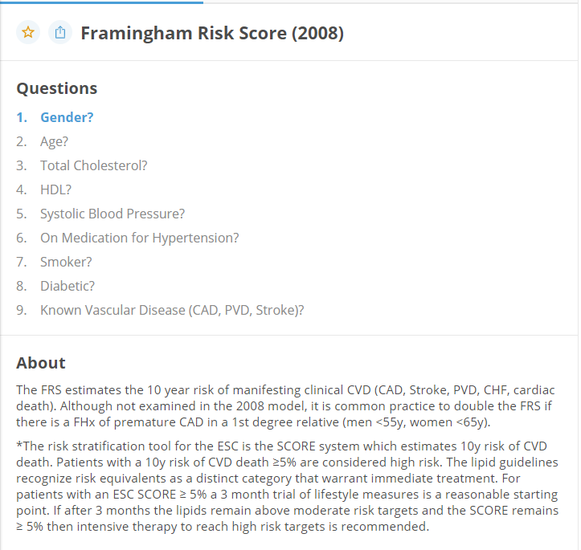

### 3.1.2 Echanges et discussions

Suite aux échanges avec l’IPL, les points retenus sont les suivants :

Comme précisé, on souhaite prendre en compte l’information sur les antécédents cardiovasculaires. Pour cela, on va regarder les variables suivantes :

- AP_AVC_ON : Accident Vasculaire Cérébral - attaque,
- AP_IAM_ON : Infractus Aigu du Myocarde,
- AP_autreMCV_ON : Maladie CardioVasculaire.

**=>** Cette information (si présente pour l’individu) permet donc de classer le niveau de risque en *élevé*.

Pour ce qui est du traitement de l’hypertension, on va regarder dans un premier temps s’il y a des antécédents d’hypertension (AP_HTA_ON),  
**=>** Si OUI, on va regarder au niveau des antécédents médicaux, concernant la classe thérapeutique : code C (système cardiovasculaire).

- Variables : Med1_ATC, Med2_ATC, Med3_ATC, …
- Classe à exclure : C01, C04, C05, C10.

## 3.2 Préparation des données

On va donc préparer les données, soit les variables nécessaires au calcul du score Framingham.

### 3.2.1 Genre/Sexe :

| Gender | Freq |
| --- | --- |
| F | 62 |
| M | 82 |
| Sum | 144 |

### 3.2.2 Age :

Un seuil est utilisé sur la variable de l’âge :

- 30 ans minimum (pour l’article et pour le calculateur), en dessous de ce seuil, on ne calcule pas le risque.

Age

| Min. | 1st Qu. | Median | Mean | 3rd Qu. | Max. |
| --- | --- | --- | --- | --- | --- |
| 21 | 42.75 | 53 | 50.52083 | 58 | 79 |

| Age vérifié (> 30 ans) | Freq |
| --- | --- |
| FALSE | 10 |
| TRUE | 134 |
| Sum | 144 |

### 3.2.3 Cholestérol HDL et total :

Conversion des unités pour le cholestérol de g/L à mg/dL en multipliant par 100 *(http://medicalcul.free.fr/conversions.html)*. Afin de se caler sur l’article et sur le package utilisé plus bas.

Cholestérol HDL

| Min. | 1st Qu. | Median | Mean | 3rd Qu. | Max. |
| --- | --- | --- | --- | --- | --- |
| 11 | 44 | 53 | 54.88889 | 64.25 | 131 |

Cholestérol Total

| Min. | 1st Qu. | Median | Mean | 3rd Qu. | Max. |
| --- | --- | --- | --- | --- | --- |
| 104 | 172.75 | 199 | 204.0625 | 233.25 | 359 |

### 3.2.4 Pression Artérielle Systolique allongée :

Pression Artérielle Sysolique

| Min. | 1st Qu. | Median | Mean | 3rd Qu. | Max. |
| --- | --- | --- | --- | --- | --- |
| 96 | 127 | 135.5 | 136.8819 | 145 | 192 |

### 3.2.5 Antécédents d’hypertension :

| Sous traitement pour l’hypertension | Freq |
| --- | --- |
| FALSE | 118 |
| TRUE | 26 |
| Sum | 144 |

### 3.2.6 Statut tabagique :

| Statut tabagique | Freq |
| --- | --- |
| FALSE | 122 |
| TRUE | 22 |
| Sum | 144 |

### 3.2.7 Statut diabétique :

Comme pour le score Métabolique, on va se baser sur le plan d’analyse qui suppose la glycémie à jeun > à 1.25 g/L.

| Statut Diabétique | Freq |
| --- | --- |
| FALSE | 140 |
| TRUE | 4 |
| Sum | 144 |

### 3.2.8 Antécédents cardiovasculaires :

==> non utilisé et non présent dans l’article ni dans le package utilisé pour calculer le score (car se basant sur l’article).  
(pas de description trouvée)

**Retour de l’IPL :** Classe le risque en “élevé” si antécédents

| AVC - accident vasculaire cérébral | Freq |
| --- | --- |
| Non | 140 |
| Oui | 4 |
| Sum | 144 |

| Infractus Aigu du Myocarde | Freq |
| --- | --- |
| Non | 141 |
| Oui | 3 |
| Sum | 144 |

| Maladie CardioVasculaire. | Freq |
| --- | --- |
| Non | 138 |
| Oui | 6 |
| Sum | 144 |

## 3.3 Calcul du score Framingham

Ici, je me suis basée sur le package R [*frisk*](https://github.com/PHP2560-Statistical-Programming-R/r-framingham), tout en prenant en compte les remarques et demandes de l’IPL, notamment la correction de seuils planchers et plafonds *(cf : Cholestérol par ex)*.

*Note :* Risk = Estimated 10-year Global CVD Risk

### 3.3.1 Score Framingham

On établit des seuils sur le score obtenu, cependant 2 seuils sont présents dans la littérature. J’ai donc décider de traiter les 2 situations :

- seuils de 0-6-20+ %
  - “We used 0% to 6%, 6% to 20%, and >20% as risk categories.” *(d’après l’article)*
- seuils de 0-10-20+ %
  - d’après documentation en ligne
    - [exemple 1](https://ccs.ca/app/uploads/2020/12/FRS_fr_2017_fnl1.pdf)…
    - exemple 2

**=>** Ces seuils servent à classer le niveau de risque de chaque individus, ainsi de 0% à 6% (respectivement 10%), le risque est *faible*. De même, de 6% (respectivement 10%) à 20%, le risque est *modéré*. Enfin, au-delà de 20%, le risque est *élevé*.

**Niveau de risque associé au score (%)**

| NiveauRisque (IPL) | Freq |
| --- | --- |
|  | 10 |
| Eleve | 30 |
| Faible | 77 |
| Modere | 27 |
| Sum | 144 |

| Niveau de risque (seuil à 6%) | Niveau de risque (seuil à 10%) Elevé | Niveau de risque (seuil à 10%) Faible | Niveau de risque (seuil à 10%) Modéré |
| --- | --- | --- | --- |
| Elevé | 33 | 0 | 0 |
| Faible | 0 | 40 | 0 |
| Modéré | 0 | 38 | 23 |

|  | Patient_ID | Genre | Age | Age check | Cholesterol HDL | Cholesterol total | Pression artérielle systolyque | sous traitement sbp | Statut tabagique | Statut diabétique | Framingham_ON | ScFramingham | NiveauRisque | AgeCardiaque | Points score | Risk | Age vasculaire estimé | AP_AVC_ON | AP_IAM_ON | AP_autreMCV_ON | Grp_C_T | risk (numeric) | niveau de risque (6/20) | niveau de risque (10/20) |
| --- | --- | --- | --- | --- | --- | --- | --- | --- | --- | --- | --- | --- | --- | --- | --- | --- | --- | --- | --- | --- | --- | --- | --- | --- |
| 1 | 1-0006 | M | 41 | True | 39 | 140 | 151 | False | False | False | Fait | 6.7 | Faible | 48 | 8 | ['6.7'] | ['48'] | Non | Non | Non | Temoin | 6.7 | Modéré | Faible |
| 2 | 1-0019 | F | 28 | False | 53 | 213 | 130 | False | False | False | Non applicable |  |  |  |  | [] | [] | Non | Non | Non | Temoin |  |  |  |
| 3 | 1-0026 | M | 39 | True | 47 | 207 | 154 | False | True | False | Fait | 9.4 | Faible | 54 | 10 | ['9.4'] | ['54'] | Non | Non | Non | Cas | 9.4 | Modéré | Faible |
| 4 | 1-0027 | M | 55 | True | 39 | 152 | 149 | False | False | False | Fait | 15.6 | Modere | 64 | 13 | ['15.6'] | ['64'] | Non | Non | Non | Cas | 15.6 | Modéré | Modéré |
| 5 | 1-0030 | M | 53 | True | 28 | 231 | 96 | True | False | False | Fait | 13.2 | Modere | 60 | 12 | ['13.2'] | ['60'] | Non | Non | Oui | Cas | 13.2 | Elevé | Elevé |
| 6 | 1-0038 | M | 56 | True | 32 | 210 | 151 | False | True | False | Fait | 30 | Eleve | 80 | 20 | ['>30'] | ['>80'] | Non | Non | Non | Temoin | 30 | Elevé | Elevé |
| 7 | 1-0045 | F | 39 | True | 51 | 155 | 192 | False | True | False | Fait | 5.3 | Faible | 55 | 9 | ['5.3'] | ['55'] | Non | Non | Non | Cas | 5.3 | Faible | Faible |
| 8 | 1-0060 | F | 54 | True | 63 | 266 | 112 | False | True | False | Fait | 5.3 | Faible | 55 | 9 | ['5.3'] | ['55'] | Non | Non | Non | Temoin | 5.3 | Faible | Faible |
| 9 | 1-0070 | M | 52 | True | 47 | 241 | 135 | False | False | False | Fait | 13.2 | Modere | 60 | 12 | ['13.2'] | ['60'] | Non | Non | Non | Cas | 13.2 | Modéré | Modéré |
| 10 | 1-0072 | M | 22 | False | 53 | 157 | 130 | False | False | False | Non applicable |  |  |  |  | [] | [] | Non | Non | Non | Temoin |  |  |  |

[output cut: 134 more lines]

### 3.3.2 Statistiques descriptives

| **Caractéristique** | **Score Framingham** **Total**, N = 144<sup>1</sup> | **Score Framingham** **Cas**, N = 72<sup>1</sup> | **Score Framingham** **Temoin**, N = 72<sup>1</sup> |
| --- | --- | --- | --- |
| Age |  |  |  |
| Médiane [25% ; 75%] | 53 [43 ; 58] | 54 [43 ; 58] | 52 [42 ; 58] |
| Moyenne [Étendue] | 51 [21 - 79] | 50 [21 - 76] | 51 [22 - 79] |
| Age_verif | 134 (93%) | 68 (94%) | 66 (92%) |
| hdl |  |  |  |
| Médiane [25% ; 75%] | 53 [44 ; 64] | 50 [41 ; 64] | 57 [44 ; 65] |
| Moyenne [Étendue] | 55 [11 - 131] | 54 [28 - 131] | 56 [11 - 95] |
| chl |  |  |  |
| Médiane [25% ; 75%] | 199 [173 ; 233] | 200 [175 ; 239] | 198 [167 ; 233] |
| Moyenne [Étendue] | 204 [104 - 359] | 210 [117 - 359] | 198 [104 - 297] |
| PAS |  |  |  |
| Médiane [25% ; 75%] | 136 [127 ; 145] | 136 [128 ; 146] | 136 [126 ; 144] |
| Moyenne [Étendue] | 137 [96 - 192] | 138 [96 - 192] | 135 [106 - 169] |
| is_sbp_under_treatment | 26 (18%) | 15 (21%) | 11 (15%) |
| smoking_status | 22 (15%) | 10 (14%) | 12 (17%) |
| diabetes_status | 4 (2,8%) | 4 (5,6%) | 0 (0%) |

<sup>1</sup> n (%)

### 3.3.3 Comparaison

|  | Patient_clean | ScFramingham | NiveauRisque | risk | Niveau_risque_diy | Niveau_risque_diy_10 |
| --- | --- | --- | --- | --- | --- | --- |
| 1 | 1-0006 | 6.7 | Faible | ['6.7'] | Modéré | Faible |
| 2 | 1-0019 |  |  | [] |  |  |
| 3 | 1-0026 | 9.4 | Faible | ['9.4'] | Modéré | Faible |
| 4 | 1-0027 | 15.6 | Modere | ['15.6'] | Modéré | Modéré |
| 5 | 1-0030 | 13.2 | Modere | ['13.2'] | Elevé | Elevé |
| 6 | 1-0038 | 30 | Eleve | ['>30'] | Elevé | Elevé |
| 7 | 1-0045 | 5.3 | Faible | ['5.3'] | Faible | Faible |
| 8 | 1-0060 | 5.3 | Faible | ['5.3'] | Faible | Faible |
| 9 | 1-0070 | 13.2 | Modere | ['13.2'] | Modéré | Modéré |
| 10 | 1-0072 |  |  | [] |  |  |

[output cut: 134 more lines]